# germination

```r
library(rethinking)
library(brms)
library(tidyverse)
```

```r
germ <- read_csv("../Dimensions/hydrothermal-all-species/data/light_round1_tall.csv") %>%
  filter(wps == 0) %>%
  select(pops, temps, total_seeds, germ, day, cumulative_germ)
germ
```

| pops | temps | total_seeds | germ | day | cumulative_germ |
| --- | --- | --- | --- | --- | --- |
| CAAM | 5 | 50 | 0 | 1 | 0 |
| CAAM | 5 | 50 | 0 | 2 | 0 |
| CAAM | 5 | 50 | 0 | 3 | 0 |
| CAAM | 5 | 50 | 0 | 4 | 0 |
| CAAM | 5 | 50 | 0 | 5 | 0 |
| CAAM | 5 | 50 | 0 | 6 | 0 |
| CAAM | 5 | 50 | 0 | 7 | 0 |
| CAAM | 5 | 50 | 0 | 8 | 0 |
| CAAM | 5 | 50 | 0 | 9 | 0 |
| CAAM | 5 | 50 | 0 | 10 | 0 |

[output cut: 990 more lines]

what if need one event per row:

```r
one_per_row <- function(df) {
  total_seed <- max(df$total_seeds, sum(df$germ))
  newdata <- tibble(id=1:total_seed, germ=0, day=max(df$day))
  df <- df %>% filter(germ>0)
  count <- 1
  if (nrow(df) > 0) {
    for (i in 1:nrow(df)) { # we look at each row of the df where germination occured
      for (j in 1:df$germ[i]) { # now update the newdata to reflect the germiantion of each seed
        newdata$germ[count] <- 1
        newdata$day[count]=df$day[i]
        count <- count+1 # count keeps track of which individual we are at in the new data
      } # for j
    } # for i
  } # if
  return(newdata)
}

germone <- germ %>% group_by(pops, temps) %>%
  select(-cumulative_germ) %>% # not needed in this encoding (I think...in any case would need to be recalculated)
  nest() %>%
  mutate(newdata=map(data, one_per_row)) %>%
  select(-data) %>%
  unnest(newdata)

germone
```

| pops | temps | id | germ | day |
| --- | --- | --- | --- | --- |
| CAAM | 5 | 1 | 0 | 28 |
| CAAM | 5 | 2 | 0 | 28 |
| CAAM | 5 | 3 | 0 | 28 |
| CAAM | 5 | 4 | 0 | 28 |
| CAAM | 5 | 5 | 0 | 28 |
| CAAM | 5 | 6 | 0 | 28 |
| CAAM | 5 | 7 | 0 | 28 |
| CAAM | 5 | 8 | 0 | 28 |
| CAAM | 5 | 9 | 0 | 28 |
| CAAM | 5 | 10 | 0 | 28 |

[output cut: 990 more lines]

## 1

Is effect of temp ~linear on cum germ?

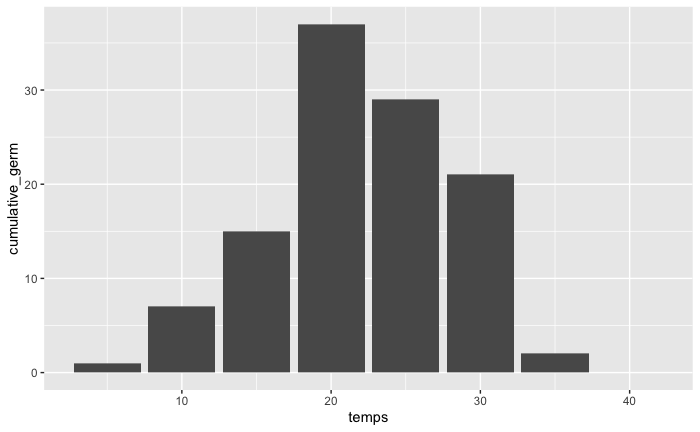

```r
germ %>% filter(pops=="STDI", day==28) %>%
  ggplot(aes(x=temps,y=cumulative_germ)) +
  geom_col()
```

no, so we can’t treat temp as a continuous linear predictor

```r
germ.stdi <- germone %>% filter(pops=="STDI") %>% select(-pops)
germ.stdi
```

| pops | temps | id | germ | day |
| --- | --- | --- | --- | --- |
| STDI | 5 | 1 | 1 | 24 |
| STDI | 5 | 2 | 0 | 28 |
| STDI | 5 | 3 | 0 | 28 |
| STDI | 5 | 4 | 0 | 28 |
| STDI | 5 | 5 | 0 | 28 |
| STDI | 5 | 6 | 0 | 28 |
| STDI | 5 | 7 | 0 | 28 |
| STDI | 5 | 8 | 0 | 28 |
| STDI | 5 | 9 | 0 | 28 |
| STDI | 5 | 10 | 0 | 28 |

[output cut: 386 more lines]

## 2

### censored exponential

#### rethinking

exponential rate curve, censoring seed that don’t germinate.

```r
d <- list(germ=germ.stdi$germ,
          temps=as.numeric(as.factor(germ.stdi$temps)),
          day=germ.stdi$day)

m1.1 <- ulam(
  alist(
    day | germ==1 ~ exponential( lambda),
    day | germ==0 ~ custom(exponential_lccdf( !Y | lambda)),
    lambda <- 1.0 / mu,
    log(mu) <- a[temps],
    a[temps] ~ normal(0,1)),
  data=d,
  chains=4,
  cores = 4
)
```

```r
precis(m1.1, depth = 2)
```

The above represent log(mean time to germination)

```r
exp(5.45)
exp(2.48)
```

posterior

```r
preddata <- expand_grid(temps=1:8, day=1:28)
pred <- link(m1.1, data = preddata)
str(pred)
```

mu is average days to germ, lambda is rate parameter. neither change over time, of course, so having days doesn’t really make sense.

```r
preddata$mu <- apply(pred$mu,2,mean)
preddata$low <- apply(pred$mu,2,HPDI)[1,]
preddata$high <- apply(pred$mu, 2, HPDI)[2,]
```

Single temp. Don’t need day posterior

```r
preddata <- expand_grid(temps=3)
pred <- link(m1.1, data = preddata)
str(pred)
```

how to convert to probs? use pexp.

```r
predprobs <- pexp(1:28,rate=pred$lambda[1])
```

```r
#plot(x=1:28,y=predprobs, type="l") # crashes on plot
```

even though it isn’t using day, including day in the prediction data frame will help me keep data in the correct format. Maybe.

```r
preddata <- expand_grid(temps=1:8, day=1:28)
pred <- link(m1.1, data = preddata)
str(pred)
```

```r
predresults <- preddata %>%
  mutate(lambda=as.list(as.data.frame(pred$lambda)))
predresults
```

```r
predresults <- predresults %>%
  mutate(probs=map2(day, lambda, ~ pexp(.x, .y)),
         mu=map_dbl(probs, mean),
         lower=map_dbl(probs, ~ HPDI(.)[1] %>% unlist()),
         upper=map_dbl(probs, ~ HPDI(.)[2]) %>% unlist())
predresults
```

```r
predresults %>% select(-lambda, -probs) %>%
  mutate(temps=factor(temps, labels=as.character(sort(unique(germ.stdi$temps))))) %>%
  ggplot(aes(x=day,y=mu,color=temps,group=temps)) +
  geom_line()
```

Add realdata:

```r
stdi.plot <- germ %>% filter(pops=="STDI") %>%
  select(day, temps, cumulative_germ, total_seeds) %>%
  mutate(temps=as.factor(temps),
         prop_germ=cumulative_germ/total_seeds)

predresults %>% select(-lambda, -probs) %>%
  mutate(temps=factor(temps, labels=as.character(sort(unique(germ.stdi$temps))))) %>%
  ggplot(aes(x=day,y=mu,color=temps,group=temps)) +
  geom_line() +
  geom_point(aes(y=prop_germ), data=stdi.plot)
```

Poor!

### brms cencsoring model

need to set up indicator for censoring.

```r
germ.stdi <- germ.stdi %>%
  mutate(cens=ifelse(germ==0, "right", "none"),
         tempsc=as.character(temps) %>% str_pad(width=2, pad="0"))
germ.stdi
```

```r
get_prior(day | cens(cens) ~ 0 + tempsc, family = exponential, data=germ.stdi)
```

```r
m1.2 <- brm(day | cens(cens) ~ 0 + tempsc,
            family = exponential(),
            set_prior("normal(0,1)", class="b"),
            data = germ.stdi, )
```

```r
summary(m1.2)
```

```r
predict(m1.2) %>% head
```

log(mean time to germination)

```r
predict(m1.2, newdata = expand_grid(tempsc=unique(germ.stdi$tempsc), cens=c("none", "right")))
```

```r
precis(m1.1, depth = 2)
```

again, these are log(mean time to germination)

lambda should be 1/mu, so

```r
#plot(1:28,pexp(1:28, 1/exp(2.48)), type="l", col="red")
#lines(1:28,pexp(1:28, 1/exp(5.60)), type="l", col="blue")
#crashes
```

```r
get_prior( day | cens(cens) ~ 0 + tempsc,
           family = Gamma(),
           data = germ.stdi)
```

```r
m1.3 <- brm(day | cens(cens) ~ 0 + tempsc,
            family = Gamma(),
            set_prior("normal(0,1)", class="b", lb=0),
            data = germ.stdi)
```

```r
summary(m1.3)
```

```r
newdata <- expand_grid(tempsc=unique(germ.stdi$tempsc), cens=c("none", "right"))
cbind(newdata, predict(m1.3, newdata = newdata))
```

The problem with these models is that they assume that the censored observations are controlled by the same process that is controlling the ones that do germinate. I do not think that is correct, we need a mixture model.

## Trying a mixture model for a ZI exponential

```r
rethinking::stancode(m1.1)
```

```r
stancode(m1.2)
```

Zero inflated, as generated by ulam:

```r
# define parameters
prob_drink <- 0.2 # 20% of days
rate_work <- 1 # average 1 manuscript per day
# sample one year of production
N <- 365
# simulate days monks drink
set.seed(365)
drink <- rbinom( N , 1 , prob_drink )
# simulate manuscripts completed
y <- (1-drink)*rpois( N , rate_work )

rethinking::stancode(ulam( alist(
  y|y>0 ~ custom( log1m(p) + poisson_lpmf(y|lambda) ),
  y|y==0 ~ custom( log_mix( p , 0 , poisson_lpmf(0|lambda) ) ),
  logit(p) <- ap,
  log(lambda) <- al,
  ap ~ dnorm(-1.5,1),
  al ~ dnorm(1,0.5)),
  data=list(y=as.integer(y)) , sample=FALSE))
```

```r
d <- list(N=nrow(germ.stdi),
          germ=germ.stdi$germ,
          temps=as.numeric(as.factor(germ.stdi$temps)),
          day=germ.stdi$day)

stanmodel1.4 <-
  "
data{
    int<lower=1> N;  // number of observations
    int germ[N];
    vector[N] day;
    int temps[N];
}
parameters{
    vector[8] a; // alphas for the linear model
    real ap; // probability of drink
}
model{
    real p;
    vector[N] lambda;
    vector[N] mu;
    a ~ normal( 0 , 1 );
    ap ~ normal( 0, 1 );
    p = ap;
    p = inv_logit(p); // inverse link function for probability drink
    for ( i in 1:N ) {
        mu[i] = a[temps[i]]; // linear model for mu
        mu[i] = exp(mu[i]);  // inverse link function part 1
        lambda[i] = 1/mu[i]; // inverse link function part 2
    }

    for ( i in 1:N )
        if ( germ[i] == 0 ) target += log_mix(p, 0, exponential_lccdf(day[i] | lambda[i]));
    for ( i in 1:N )
        if ( germ[i] == 1 ) target += log1m(p) +  exponential_lpdf(day[i] | lambda[i]);
    for ( i in 1:N )
        if ( germ[i] == 1 ) day[i] ~ exponential( lambda[i] );
}
"
m1.4 <- stan(model_code=stanmodel1.4, data=d)
```

```r
precis(m1.4, depth = 2)
```

Model 1.4 fits a single dormancy rate for all, but probably we need to have separate dormancy rate for each temp

take a look at stancode for a binomial model to see what this looks like

```r
db <- list(cumulative_germ=germ$cumulative_germ, temps=as.numeric(as.factor(germ$temps)))

rethinking::stancode(ulam(alist(
  cumulative_germ ~ dbern(mu),
  mu <- logit(a + b[temps]),
  a ~ dnorm(0,1),
  b[temps] ~ dnorm(0,1)),
  data = db, sample=FALSE, log_lik = TRUE))
```

There is no inverse logit because it is built in to the berouli function

Try to write a model with different dormancy probs for the different temps.

```r
d <- list(N=nrow(germ.stdi),
          germ=germ.stdi$germ,
          temps=as.numeric(as.factor(germ.stdi$temps)),
          day=germ.stdi$day)

stanmodel1.5 <-
  "
data{
    int<lower=1> N;  // number of observations
    int germ[N];
    vector[N] day;
    int temps[N];
}
parameters{
    vector[8] a; // alpha for the exponential curve, one for each temp
    vector[8] ap; // alpha for the proportion dormant, one for each temp
}
model{
    vector[N] p;
    vector[N] lambda;
    vector[N] mu;
    a ~ normal( 0 , 1 );
    ap ~ normal( 0, 1 );
    for (i in 1:N) {
        p[i] = ap[temps[i]];
        p[i] = inv_logit(p[i]); // inverse link function
    }
    for ( i in 1:N ) {
        mu[i] = a[temps[i]];
        mu[i] = exp(mu[i]); // inverse link function
    }
    for ( i in 1:N ) {
        lambda[i] = 1/mu[i];
    }
    for ( i in 1:N )
        if ( germ[i] == 0 ) target += log_mix(p[i], 0, exponential_lccdf(day[i] | lambda[i]));
    for ( i in 1:N )
        if ( germ[i] == 1 ) target += log1m(p[i]) +  exponential_lpdf(day[i] | lambda[i]);
    for ( i in 1:N )
        if ( germ[i] == 1 ) day[i] ~ exponential( lambda[i] );
}
"
m1.5 <- stan(model_code=stanmodel1.5, data=d)
```

```r
precis(m1.5, depth = 2)
```

|  | mean | sd | 5.5% | 94.5% | n_eff | Rhat4 |
| --- | --- | --- | --- | --- | --- | --- |
| a[1] | 2.78 | 0.58 | 1.95 | 3.76 | 3511 | 1 |
| a[2] | 1.53 | 0.27 | 1.13 | 1.97 | 5809 | 1 |
| a[3] | 1.35 | 0.18 | 1.07 | 1.64 | 6656 | 1 |
| a[4] | 1.01 | 0.11 | 0.82 | 1.19 | 6949 | 1 |
| a[5] | 1.16 | 0.13 | 0.95 | 1.38 | 7090 | 1 |
| a[6] | 2.34 | 0.18 | 2.07 | 2.63 | 6338 | 1 |
| a[7] | 2.41 | 0.49 | 1.70 | 3.27 | 6388 | 1 |
| a[8] | 0.03 | 1.06 | -1.64 | 1.70 | 7810 | 1 |
| ap[1] | 2.41 | 0.57 | 1.51 | 3.32 | 4708 | 1 |
| ap[2] | 1.60 | 0.35 | 1.05 | 2.18 | 7056 | 1 |

[output cut: 6 more lines]

```r
shinystan::launch_shinystan(m1.5)
```

```r
post <- as.data.frame(m1.5)
head(post)
```

|  | a[1] | a[2] | a[3] | a[4] | a[5] | a[6] | a[7] | a[8] | ap[1] | ap[2] | ap[3] | ap[4] | ap[5] | ap[6] | ap[7] | ap[8] | lp__ |
| --- | --- | --- | --- | --- | --- | --- | --- | --- | --- | --- | --- | --- | --- | --- | --- | --- | --- |
| 1 | 2.547893 | 1.735660 | 1.105927 | 1.1715571 | 1.171425 | 2.378229 | 2.995813 | 1.4542387 | 2.354302 | 1.971745 | 1.2087152 | -1.2218568 | -0.6303942 | 0.2344644 | 1.641194 | 3.081805 | -738.2014 |
| 2 | 2.583034 | 1.070712 | 1.510873 | 0.8891116 | 1.139326 | 2.417775 | 1.783368 | -1.5305007 | 2.492442 | 1.246675 | 0.5555402 | -0.7648902 | 0.0949008 | 0.1646990 | 2.870000 | 2.376519 | -738.4555 |
| 3 | 2.424704 | 1.062681 | 1.654150 | 0.9288301 | 1.215713 | 2.409243 | 2.043413 | -0.7483362 | 2.770481 | 1.488187 | 0.7008078 | -0.7713064 | -0.1343890 | 0.2499608 | 2.407950 | 2.133697 | -736.4256 |
| 4 | 2.914547 | 2.083798 | 1.147133 | 1.0291078 | 1.173556 | 2.480500 | 2.480741 | 0.8806243 | 2.300084 | 1.751221 | 1.1221827 | -1.0221295 | -0.2655500 | 0.6809781 | 2.044803 | 4.007230 | -739.0916 |
| 5 | 2.050532 | 1.263580 | 1.288306 | 0.8551287 | 1.044356 | 2.509232 | 3.085415 | -2.5139289 | 2.628432 | 1.947161 | 0.8846764 | -0.6532045 | -0.2248582 | 0.1542867 | 1.724847 | 2.888336 | -738.9594 |
| 6 | 2.691913 | 1.819447 | 1.423968 | 1.0201649 | 1.000563 | 2.108176 | 2.318939 | -1.4424487 | 3.888814 | 1.291378 | 0.8218196 | -1.1413853 | -0.2017027 | -0.1064789 | 2.540707 | 2.684071 | -739.0371 |

now need to make predictions

```r
post_logavgdays <- post %>% select(starts_with("a["
)) # these are the log(mean(avg time to germinate))
mu_lambda <- post_logavgdays %>%
  summarise_all(mean) %>% # posterior mean
  mutate_all(~ 1/exp(.)) # convert to lambda (inverse link)
mu_lambda
```

| a[1] | a[2] | a[3] | a[4] | a[5] | a[6] | a[7] | a[8] |
| --- | --- | --- | --- | --- | --- | --- | --- |
| 0.06173861 | 0.2166748 | 0.2597516 | 0.3659854 | 0.3148635 | 0.09611463 | 0.08939125 | 0.9704007 |

```r
post_logitp <- post %>% select(starts_with("ap")) #logit p dormant
mu_p <- post_logitp %>%
  summarize_all(mean) %>%
  mutate_all(inv_logit)
mu_p
```

| ap[1] | ap[2] | ap[3] | ap[4] | ap[5] | ap[6] | ap[7] | ap[8] |
| --- | --- | --- | --- | --- | --- | --- | --- |
| 0.9179183 | 0.8314135 | 0.6862877 | 0.2760073 | 0.4246717 | 0.5423409 | 0.9007833 | 0.9481688 |

```r
posterior_coef <- tibble(temps=as.factor(unique(germ.stdi$temps)),
                        lambda=t(mu_lambda),
                        p=t(mu_p))
```

plot, include original data

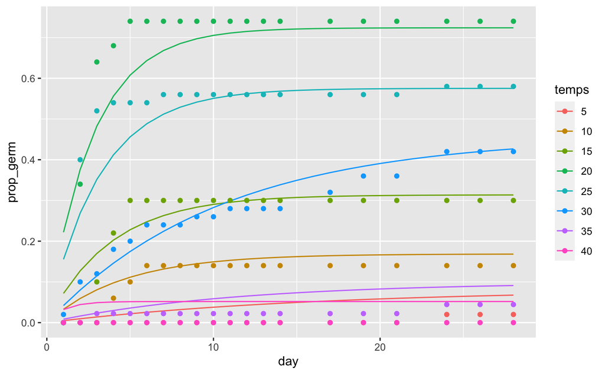

```r
post_plot <- expand_grid(posterior_coef, day=1:28) %>%
  mutate(prop_germ=pexp(day, rate=lambda) * (1-p))

stdi.plot <- germ %>% filter(pops=="STDI") %>%
  select(day, temps, cumulative_germ, total_seeds) %>%
  mutate(temps=as.factor(temps),
         prop_germ=cumulative_germ/total_seeds)

post_plot %>%
  ggplot(aes(x=day,y=prop_germ,color=temps,group=temps)) +
  geom_line() +
  geom_point(data=stdi.plot)
```

```r
NA
```

adjust priors

```r
d <- list(N=nrow(germ.stdi),
          germ=germ.stdi$germ,
          temps=as.numeric(as.factor(germ.stdi$temps)),
          day=germ.stdi$day)

stanmodel1.5a <-
  "
data{
    int<lower=1> N;  // number of observations
    int germ[N];
    vector[N] day;
    int temps[N];
}
parameters{
    vector[8] a; // alpha for the exponential curve, one for each temp
    vector[8] ap; // alpha for the proportion dormant, one for each temp
}
model{
    vector[N] p;
    vector[N] lambda;
    vector[N] mu;
    a ~ normal( 0 , 2 );
    ap ~ normal( 0, 2 );
    for (i in 1:N) {
        p[i] = ap[temps[i]];
        p[i] = inv_logit(p[i]); // inverse link function
    }
    for ( i in 1:N ) {
        mu[i] = a[temps[i]];
        mu[i] = exp(mu[i]); // inverse link function
    }
    for ( i in 1:N ) {
        lambda[i] = 1/mu[i];
    }
    for ( i in 1:N )
        if ( germ[i] == 0 ) target += log_mix(p[i], 0, exponential_lccdf(day[i] | lambda[i]));
    for ( i in 1:N )
        if ( germ[i] == 1 ) target += log1m(p[i]) +  exponential_lpdf(day[i] | lambda[i]);
    for ( i in 1:N )
        if ( germ[i] == 1 ) day[i] ~ exponential( lambda[i] );
}
"
m1.5a <- stan(model_code=stanmodel1.5a, data=d)
```

```r
precis(m1.5a, depth = 2)
```

|  | mean | sd | 5.5% | 94.5% | n_eff | Rhat4 |
| --- | --- | --- | --- | --- | --- | --- |
| a[1] | 3.64 | 0.89 | 2.36 | 5.20 | 2112 | 1 |
| a[2] | 1.60 | 0.28 | 1.19 | 2.07 | 4081 | 1 |
| a[3] | 1.38 | 0.19 | 1.09 | 1.70 | 4456 | 1 |
| a[4] | 1.02 | 0.12 | 0.83 | 1.21 | 5548 | 1 |
| a[5] | 1.17 | 0.13 | 0.96 | 1.39 | 4776 | 1 |
| a[6] | 2.40 | 0.18 | 2.12 | 2.71 | 4403 | 1 |
| a[7] | 2.92 | 0.68 | 1.99 | 4.16 | 2092 | 1 |
| a[8] | 0.63 | 2.52 | -3.09 | 5.00 | 2403 | 1 |
| ap[1] | 2.73 | 1.11 | 1.01 | 4.38 | 2321 | 1 |
| ap[2] | 1.79 | 0.40 | 1.19 | 2.46 | 4655 | 1 |

[output cut: 6 more lines]

```r
shinystan::launch_shinystan(m1.5a)
```

```r
post <- as.data.frame(m1.5a)

post_logavgdays <- post %>% select(starts_with("a["
)) # these are the log(mean(avg time to germinate))
mu_lambda <- post_logavgdays %>%
  summarise_all(mean) %>% # posterior mean
  mutate_all(~ 1/exp(.)) # convert to lambda (inverse link)
mu_lambda
```

| a[1] | a[2] | a[3] | a[4] | a[5] | a[6] | a[7] | a[8] |
| --- | --- | --- | --- | --- | --- | --- | --- |
| 0.02620464 | 0.2009332 | 0.250733 | 0.3620094 | 0.3097339 | 0.09068685 | 0.0537127 | 0.5320585 |

```r
post_logitp <- post %>% select(starts_with("ap")) #logit p dormant
mu_p <- post_logitp %>%
  summarize_all(mean) %>%
  mutate_all(inv_logit)
mu_p
```

| ap[1] | ap[2] | ap[3] | ap[4] | ap[5] | ap[6] | ap[7] | ap[8] |
| --- | --- | --- | --- | --- | --- | --- | --- |
| 0.9386693 | 0.8569439 | 0.6979358 | 0.2604755 | 0.4211194 | 0.539168 | 0.9294409 | 0.9817392 |

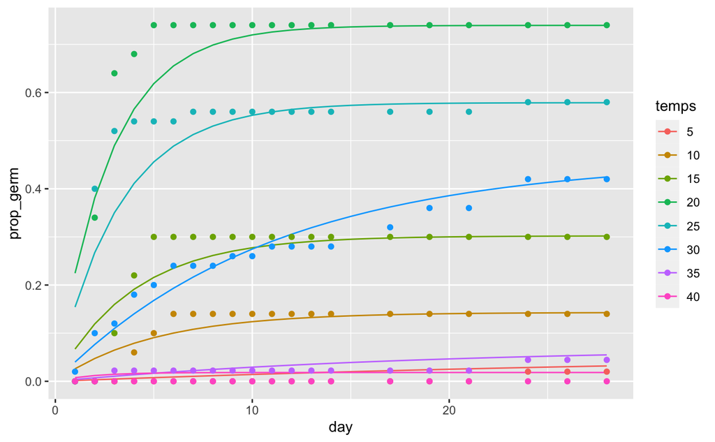

```r
posterior_coef <- tibble(temps=as.factor(unique(germ.stdi$temps)),
                        lambda=t(mu_lambda),
                        p=t(mu_p))

post_plot <- expand_grid(posterior_coef, day=1:28) %>%
  mutate(prop_germ=pexp(day, rate=lambda) * (1-p))

stdi.plot <- germ %>% filter(pops=="STDI") %>%
  select(day, temps, cumulative_germ, total_seeds) %>%
  mutate(temps=as.factor(temps),
         prop_germ=cumulative_germ/total_seeds)

post_plot %>%
  ggplot(aes(x=day,y=prop_germ,color=temps,group=temps)) +
  geom_line() +
  geom_point(data=stdi.plot)
```

```r
NA
```

still not great

### gamma

Look at gamma stancode from brms:

```r
make_stancode(day ~ tempsc,
             family="gamma",
             prior=set_prior("normal(0,1)"),
             data=germ.stdi,
             sample=FALSE)
```

Try developing a ZI gamma model:

stan uses that gamma(alpha, beta) parameterization where “alpha” is shape" and “beta” is “rate”. So try having the shape be the same for all temps.

```r
d <- list(N=nrow(germ.stdi),
          germ=germ.stdi$germ,
          temps=as.numeric(as.factor(germ.stdi$temps)),
          day=germ.stdi$day)

stanmodel1.7 <-
  "
data{
    int<lower=1> N;  // number of observations
    int germ[N];
    vector[N] day;
    int temps[N];
}
parameters{
    real<lower=0> shape; // should set lower bound
    vector[8] a; // alpha for the gamma curve, one for each temp
    vector[8] ap; // alpha for the proportion dormant, one for each temp
}
model{
    vector[N] p;
    vector[N] mu;
    a ~ normal( 0 , .5 ); //narrow priors to overcome divergent transitions
    ap ~ normal( 0, 1.5 );
    shape ~ normal(0, .5); //narrow priors to overcome divergent transitions
    for (i in 1:N) {
        p[i] = ap[temps[i]];
        p[i] = inv_logit(p[i]);
    }
    for ( i in 1:N ) {
        mu[i] = a[temps[i]];
         // apply the inverse link function
        mu[i] = shape * exp(-(mu[i]));
    }
    for ( i in 1:N )
       if ( germ[i] == 0 ) target += log_mix(p[i], 0, gamma_lccdf(day[i] | shape, mu[i]));
    for ( i in 1:N )
       if ( germ[i] == 1 ) target += log1m(p[i]) + gamma_lpdf(day[i] | shape, mu[i]);
    for ( i in 1:N )
       if ( germ[i] == 1 ) day[i] ~ gamma( shape, mu[i] );
}
"
m1.7 <- stan(model_code=stanmodel1.7, data=d, chains=4, cores=4, control=list(adapt_delta=.99))
```

```
starting worker pid=8464 on localhost:11321 at 21:22:16.836
starting worker pid=8478 on localhost:11321 at 21:22:17.142
starting worker pid=8492 on localhost:11321 at 21:22:17.448
starting worker pid=8506 on localhost:11321 at 21:22:17.737




Iteration: 1800 / 2000 [ 90%]  (Sampling)
```

```r
precis(m1.7, depth = 2)
```

|  | mean | sd | 5.5% | 94.5% | n_eff | Rhat4 |
| --- | --- | --- | --- | --- | --- | --- |
| shape | 2.35 | 0.20 | 2.05 | 2.68 | 5664 | 1 |
| a[1] | 2.18 | 0.25 | 1.79 | 2.58 | 5134 | 1 |
| a[2] | 1.43 | 0.15 | 1.20 | 1.68 | 5682 | 1 |
| a[3] | 1.30 | 0.11 | 1.12 | 1.48 | 5973 | 1 |
| a[4] | 1.00 | 0.07 | 0.88 | 1.12 | 6094 | 1 |
| a[5] | 1.13 | 0.08 | 1.01 | 1.27 | 5801 | 1 |
| a[6] | 2.21 | 0.10 | 2.06 | 2.37 | 4873 | 1 |
| a[7] | 2.01 | 0.22 | 1.66 | 2.38 | 5881 | 1 |
| a[8] | 0.01 | 0.49 | -0.79 | 0.78 | 5596 | 1 |
| ap[1] | 3.15 | 0.65 | 2.21 | 4.24 | 4445 | 1 |

[output cut: 7 more lines]

```r
shinystan::launch_shinystan(m1.7)
```

```
Launching ShinyStan interface... for large models this  may take some time.

Listening on http://127.0.0.1:7960
```

```
NA
```

```r
post <- as.data.frame(m1.7)
head(post)
```

|  | shape | a[1] | a[2] | a[3] | a[4] | a[5] | a[6] | a[7] | a[8] | ap[1] | ap[2] | ap[3] | ap[4] | ap[5] | ap[6] | ap[7] | ap[8] | lp__ |
| --- | --- | --- | --- | --- | --- | --- | --- | --- | --- | --- | --- | --- | --- | --- | --- | --- | --- | --- |
| 1 | 2.681030 | 2.418374 | 1.480787 | 1.338589 | 0.9809867 | 1.091044 | 2.094993 | 1.770279 | -0.1551213 | 3.251169 | 1.721217 | 0.9277305 | -0.5813300 | -1.01969675 | -0.1311020 | 3.006550 | 3.474535 | -721.5998 |
| 2 | 2.005577 | 1.776708 | 1.327217 | 1.342285 | 0.9948139 | 1.154872 | 2.301480 | 2.180992 | 0.1532737 | 3.077747 | 1.822239 | 0.7020798 | -1.5128819 | 0.35997314 | 0.7638256 | 2.159832 | 3.438068 | -722.9321 |
| 3 | 2.564495 | 2.039211 | 1.666710 | 1.280632 | 1.1214005 | 1.209362 | 2.233938 | 1.892641 | -0.7248224 | 3.936129 | 1.917818 | 0.5667677 | -1.3210133 | -0.45199471 | -0.4413232 | 3.086216 | 2.514036 | -724.6422 |
| 4 | 2.240523 | 2.359230 | 1.322191 | 1.300449 | 0.8590055 | 1.062089 | 2.214325 | 2.172904 | 0.3495346 | 2.193717 | 1.353038 | 1.0128321 | -0.6416337 | -0.11642503 | 0.9310057 | 2.235174 | 4.528103 | -722.3378 |
| 5 | 2.328929 | 1.856659 | 1.483901 | 1.255212 | 1.0964885 | 1.196587 | 2.151067 | 1.769383 | -0.3579942 | 4.000002 | 2.036688 | 0.6808125 | -1.4223254 | -0.50102056 | -0.3035165 | 2.930973 | 2.685809 | -721.6731 |
| 6 | 2.429575 | 2.473882 | 1.410895 | 1.390883 | 0.9063888 | 1.159352 | 2.267617 | 2.113087 | 0.4005048 | 2.184835 | 1.233664 | 0.6449832 | -0.6188843 | -0.02863094 | 1.0259740 | 2.388058 | 4.246563 | -722.2486 |

now need to make predictions

```r
post_logavgdays <- post %>% select(shape, starts_with("a["
)) # these are the shape and the log(mean(avg time to germinate))
mu_rate <- post_logavgdays %>%
  mutate(across(-shape, ~ shape*exp(-(.))) ) %>%
  summarize(across(everything(), mean)) %>% select(-shape) # posterior mean
mu_rate
```

| a[1] | a[2] | a[3] | a[4] | a[5] | a[6] | a[7] | a[8] |
| --- | --- | --- | --- | --- | --- | --- | --- |
| 0.2746951 | 0.5675486 | 0.6442107 | 0.8719563 | 0.7595863 | 0.2587711 | 0.3211634 | 2.628165 |

```r
mu_shape <- mean(post$shape)
mu_shape
```

```
[1] 2.354284
```

```r
post_logitp <- post %>% select(starts_with("ap")) #logit p dormant
mu_p <- post_logitp %>%
  summarize_all(mean) %>%
  mutate_all(inv_logit)
mu_p
```

| ap[1] | ap[2] | ap[3] | ap[4] | ap[5] | ap[6] | ap[7] | ap[8] |
| --- | --- | --- | --- | --- | --- | --- | --- |
| 0.9589621 | 0.852257 | 0.6965797 | 0.2639963 | 0.4216266 | 0.5728951 | 0.9371412 | 0.9750132 |

plot predictions and original data

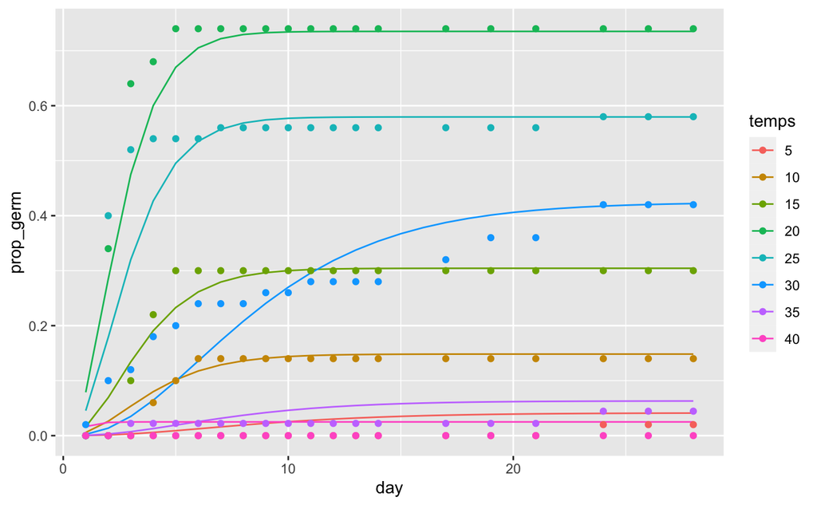

```r
posterior_coef <- tibble(shape=mu_shape, temps=as.factor(unique(germ.stdi$temps)),
                        rate=t(mu_rate),
                        p=t(mu_p))

post_plot <- expand_grid(posterior_coef, day=1:28) %>%
  mutate(prop_germ=pgamma(day, shape=mu_shape, rate=rate) * (1-p))

stdi.plot <- germ %>% filter(pops=="STDI") %>%
  select(day, temps, cumulative_germ, total_seeds) %>%
  mutate(temps=as.factor(temps),
         prop_germ=cumulative_germ/total_seeds)

post_plot %>%
  ggplot(aes(x=day,y=prop_germ,color=temps,group=temps)) +
  geom_line() +
  geom_point(data=stdi.plot)
```

```r
NA
```

#### playing with priors:

```r
d <- list(N=nrow(germ.stdi),
          germ=germ.stdi$germ,
          temps=as.numeric(as.factor(germ.stdi$temps)),
          day=germ.stdi$day)

stanmodel1.7a <-
  "
data{
    int<lower=1> N;  // number of observations
    int germ[N];
    vector[N] day;
    int temps[N];
}
parameters{
    real<lower=0> shape; // should set lower bound
    vector[8] a; // alpha for the gamma curve, one for each temp
    vector[8] ap; // alpha for the proportion dormant, one for each temp
}
model{
    vector[N] p;
    vector[N] mu;
    a ~ normal( 0 , .5 ); //narrow priors to overcome divergent transitions
    ap ~ normal( 0, 1.5 );
    shape ~ exponential(.5);
    for (i in 1:N) {
        p[i] = ap[temps[i]];
        p[i] = inv_logit(p[i]);
    }
    for ( i in 1:N ) {
        mu[i] = a[temps[i]];
         // apply the inverse link function
        mu[i] = shape * exp(-(mu[i]));
    }
    for ( i in 1:N )
       if ( germ[i] == 0 ) target += log_mix(p[i], 0, gamma_lccdf(day[i] | shape, mu[i]));
    for ( i in 1:N )
       if ( germ[i] == 1 ) target += log1m(p[i]) + gamma_lpdf(day[i] | shape, mu[i]);
    for ( i in 1:N )
       if ( germ[i] == 1 ) day[i] ~ gamma( shape, mu[i] );
}
"
m1.7a <- stan(model_code=stanmodel1.7a, data=d, chains=4, cores=4, control=list(adapt_delta=.99))
```

```r
precis(m1.7a, depth = 2)
```

|  | mean | sd | 5.5% | 94.5% | n_eff | Rhat4 |
| --- | --- | --- | --- | --- | --- | --- |
| shape | 2.89 | 0.27 | 2.47 | 3.34 | 4772 | 1 |
| a[1] | 2.28 | 0.25 | 1.89 | 2.69 | 4982 | 1 |
| a[2] | 1.45 | 0.14 | 1.23 | 1.68 | 6392 | 1 |
| a[3] | 1.32 | 0.10 | 1.16 | 1.48 | 5376 | 1 |
| a[4] | 1.00 | 0.07 | 0.89 | 1.10 | 4902 | 1 |
| a[5] | 1.14 | 0.08 | 1.02 | 1.26 | 5297 | 1 |
| a[6] | 2.22 | 0.09 | 2.08 | 2.36 | 5648 | 1 |
| a[7] | 2.09 | 0.22 | 1.75 | 2.45 | 4241 | 1 |
| a[8] | 0.00 | 0.50 | -0.81 | 0.81 | 5079 | 1 |
| ap[1] | 3.14 | 0.66 | 2.18 | 4.28 | 3381 | 1 |

[output cut: 7 more lines]

```r
post <- as.data.frame(m1.7a)

post_logavgdays <- post %>% select(shape, starts_with("a["
)) # these are the shape and the log(mean(avg time to germinate))
mu_rate <- post_logavgdays %>%
  mutate(across(-shape, ~ shape*exp(-(.))) ) %>%
  summarize(across(everything(), mean)) %>% select(-shape) # posterior mean
mu_rate
```

| a[1] | a[2] | a[3] | a[4] | a[5] | a[6] | a[7] | a[8] |
| --- | --- | --- | --- | --- | --- | --- | --- |
| 0.3039284 | 0.6802258 | 0.7774014 | 1.067306 | 0.924928 | 0.3152066 | 0.3658832 | 3.286133 |

```r
mu_shape <- mean(post$shape)

post_logitp <- post %>% select(starts_with("ap")) #logit p dormant
mu_p <- post_logitp %>%
  summarize_all(mean) %>%
  mutate_all(inv_logit)
mu_p
```

| ap[1] | ap[2] | ap[3] | ap[4] | ap[5] | ap[6] | ap[7] | ap[8] |
| --- | --- | --- | --- | --- | --- | --- | --- |
| 0.958683 | 0.8516933 | 0.6956274 | 0.2648754 | 0.4204192 | 0.5753963 | 0.9369127 | 0.9750769 |

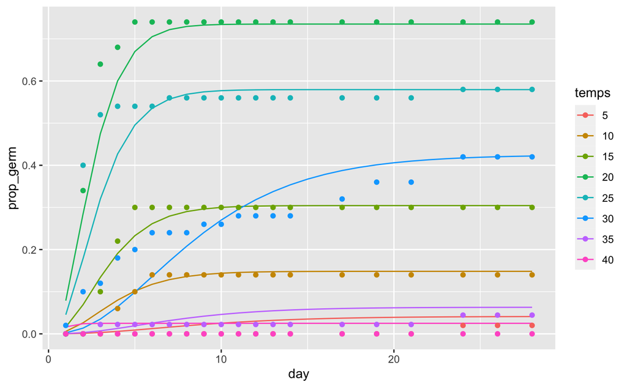

```r
posterior_coef <- tibble(shape=mu_shape, temps=as.factor(unique(germ.stdi$temps)),
                        rate=t(mu_rate),
                        p=t(mu_p))

post_plot <- expand_grid(posterior_coef, day=1:28) %>%
  mutate(prop_germ=pgamma(day, shape=mu_shape, rate=rate) * (1-p))

stdi.plot <- germ %>% filter(pops=="STDI") %>%
  select(day, temps, cumulative_germ, total_seeds) %>%
  mutate(temps=as.factor(temps),
         prop_germ=cumulative_germ/total_seeds)

post_plot %>%
  ggplot(aes(x=day,y=prop_germ,color=temps,group=temps)) +
  geom_line() +
  geom_point(data=stdi.plot)
```

```r
NA
```

Shape parameter is larger than in 1.7, but at first glance doesn’t seem to have mattered much. Could plot together.

continue to work with priors

```r
d <- list(N=nrow(germ.stdi),
          germ=germ.stdi$germ,
          temps=as.numeric(as.factor(germ.stdi$temps)),
          day=germ.stdi$day)

stanmodel1.7b <-
  "
data{
    int<lower=1> N;  // number of observations
    int germ[N];
    vector[N] day;
    int temps[N];
}
parameters{
    real<lower=0> shape; // should set lower bound
    vector[8] a; // alpha for the gamma curve, one for each temp
    vector[8] ap; // alpha for the proportion dormant, one for each temp
}
model{
    vector[N] p;
    vector[N] mu;
    a ~ normal( 0 , .75 );
    ap ~ normal( 0, 1.5 );
    shape ~ exponential(1.5); // divergent if this is .5 and a is 0, 1
    for (i in 1:N) {
        p[i] = ap[temps[i]];
        p[i] = inv_logit(p[i]);
    }
    for ( i in 1:N ) {
        mu[i] = a[temps[i]];
         // apply the inverse link function
        mu[i] = shape * exp(-(mu[i]));
    }
    for ( i in 1:N )
       if ( germ[i] == 0 ) target += log_mix(p[i], 0, gamma_lccdf(day[i] | shape, mu[i]));
    for ( i in 1:N )
       if ( germ[i] == 1 ) target += log1m(p[i]) + gamma_lpdf(day[i] | shape, mu[i]);
    for ( i in 1:N )
       if ( germ[i] == 1 ) day[i] ~ gamma( shape, mu[i] );
}
"
m1.7b <- stan(model_code=stanmodel1.7b, data=d, chains=4, cores=4, control=list(adapt_delta=.99))
```

```
starting worker pid=9700 on localhost:11321 at 22:02:29.392
starting worker pid=9714 on localhost:11321 at 22:02:29.642
starting worker pid=9728 on localhost:11321 at 22:02:29.901
starting worker pid=9742 on localhost:11321 at 22:02:30.170
```

```
There were 28 divergent transitions after warmup. Increasing adapt_delta above 0.99 may help. See
http://mc-stan.org/misc/warnings.html#divergent-transitions-after-warmupExamine the pairs() plot to diagnose sampling problems
```

```r
precis(m1.7b, depth = 2)
```

|  | mean | sd | 5.5% | 94.5% | n_eff | Rhat4 |
| --- | --- | --- | --- | --- | --- | --- |
| shape | 2.93 | 0.27 | 2.51 | 3.37 | 5983 | 1 |
| a[1] | 2.73 | 0.34 | 2.23 | 3.30 | 4811 | 1 |
| a[2] | 1.53 | 0.15 | 1.30 | 1.76 | 5763 | 1 |
| a[3] | 1.35 | 0.11 | 1.18 | 1.52 | 6209 | 1 |
| a[4] | 1.01 | 0.07 | 0.90 | 1.12 | 5517 | 1 |
| a[5] | 1.16 | 0.08 | 1.04 | 1.28 | 6073 | 1 |
| a[6] | 2.26 | 0.09 | 2.11 | 2.42 | 5839 | 1 |
| a[7] | 2.36 | 0.26 | 1.97 | 2.79 | 5601 | 1 |
| a[8] | -0.02 | 0.75 | -1.23 | 1.16 | 6502 | 1 |
| ap[1] | 3.01 | 0.69 | 2.01 | 4.13 | 4028 | 1 |

[output cut: 7 more lines]

```r
post <- as.data.frame(m1.7b)

post_logavgdays <- post %>% select(shape, starts_with("a["
)) # these are the shape and the log(mean(avg time to germinate))
mu_rate <- post_logavgdays %>%
  mutate(across(-shape, ~ shape*exp(-(.))) ) %>%
  summarize(across(everything(), mean)) %>% select(-shape) # posterior mean
mu_rate
```

| a[1] | a[2] | a[3] | a[4] | a[5] | a[6] | a[7] | a[8] |
| --- | --- | --- | --- | --- | --- | --- | --- |
| 0.2015406 | 0.6433708 | 0.7650792 | 1.072015 | 0.9247331 | 0.3061146 | 0.2840339 | 3.926208 |

```r
mu_shape <- mean(post$shape)

post_logitp <- post %>% select(starts_with("ap")) #logit p dormant
mu_p <- post_logitp %>%
  summarize_all(mean) %>%
  mutate_all(inv_logit)
mu_p
```

| ap[1] | ap[2] | ap[3] | ap[4] | ap[5] | ap[6] | ap[7] | ap[8] |
| --- | --- | --- | --- | --- | --- | --- | --- |
| 0.9530245 | 0.8510549 | 0.6962027 | 0.2652173 | 0.4207755 | 0.5747148 | 0.9349147 | 0.9749255 |

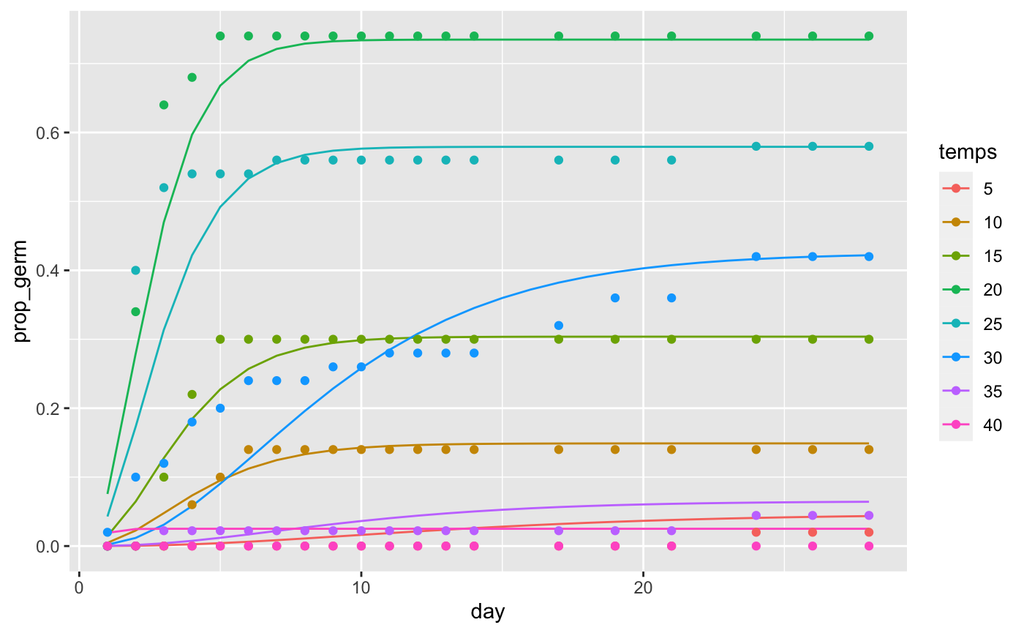

```r
posterior_coef <- tibble(shape=mu_shape, temps=as.factor(unique(germ.stdi$temps)),
                        rate=t(mu_rate),
                        p=t(mu_p))

post_plot <- expand_grid(posterior_coef, day=1:28) %>%
  mutate(prop_germ=pgamma(day, shape=mu_shape, rate=rate) * (1-p))

stdi.plot <- germ %>% filter(pops=="STDI") %>%
  select(day, temps, cumulative_germ, total_seeds) %>%
  mutate(temps=as.factor(temps),
         prop_germ=cumulative_germ/total_seeds)

post_plot %>%
  ggplot(aes(x=day,y=prop_germ,color=temps,group=temps)) +
  geom_line() +
  geom_point(data=stdi.plot)
```

```r
NA
```

### brms hurdle gamma

```r
get_prior(bf(day ~ 0 + tempsc, hu ~ 0 + tempsc),
          family = hurdle_gamma,
          data=germ.stdi)
```

```r
make_stancode(bf(day ~ 0 + tempsc, hu ~ 0 + tempsc),
          family = hurdle_gamma,
          prior=set_prior("normal(0,1)"),
          data=germ.stdi)
```

```r
m1.8 <- brm(bf(day ~ 0 + tempsc, hu ~ 0 + tempsc),
          family = hurdle_gamma,
          prior=c(set_prior("normal(0,1)"),
                  set_prior("normal(0,1)", dpar="hu")), # must specify this!
          data=germ.stdi, cores = 4)
```

```r
m1.8
```

```r
post <- as.data.frame(m1.8)
head(post)
```

weird fit!

now need to make predictions

```r
post_logavgdays <- post %>% select(shape, starts_with("b_temp"
)) # these are the shape and the log(mean(avg time to germinate))
mu_rate <- post_logavgdays %>%
  mutate(across(-shape, ~ shape*exp(-(.))) ) %>%
  summarize(across(everything(), mean)) %>% select(-shape) # posterior mean
mu_rate
mu_shape <- mean(post$shape)
```

```r
post_logitp <- post %>% select(starts_with("b_hu")) #logit p dormant
mu_p <- post_logitp %>%
  summarize_all(mean) %>%
  mutate_all(inv_logit)
mu_p
```

```r
posterior_coef <- tibble(shape=mu_shape, temps=as.factor(unique(germ.stdi$temps)),
                        rate=t(mu_rate),
                        p=t(mu_p))
```

plot predictions and original data

```r
stdi.plot <- germ %>% filter(pops=="STDI") %>%
  select(day, temps, cumulative_germ, total_seeds) %>%
  mutate(temps=as.factor(temps),
         prop_germ=cumulative_germ/total_seeds)

post_plot %>%
  ggplot(aes(x=day,y=prop_germ,color=temps,group=temps)) +
  geom_line() +
  geom_point(data=stdi.plot)
```

## allow both shape and rate of ZI gamma to vary

Need to think about link functions…

## how can we switch this around to use day as a predictor?